# susmitanew.Rmd

susmita ray

Monday, May 16, 2016

#### The program starts from here

Loading the necessary packages **************************

```r
library(datasets)
library(knitr)
library(lubridate)
```

```r
library(ggplot2)
library(lattice)
rm(list=ls())
```

Reading the data from a comma separated file into a dataframe and cleaning it **********************

```r
rawdata <- read.csv("activity.csv",header = TRUE, sep = ',', colClasses = c("numeric", "character","integer"))
rawdata$date <- ymd(rawdata$date)
head(rawdata)
```

```
##   steps       date interval
## 1    NA 2012-10-01        0
## 2    NA 2012-10-01        5
## 3    NA 2012-10-01       10
## 4    NA 2012-10-01       15
## 5    NA 2012-10-01       20
## 6    NA 2012-10-01       25
```

[output not shown]

Histogram of total no of steps taken per day

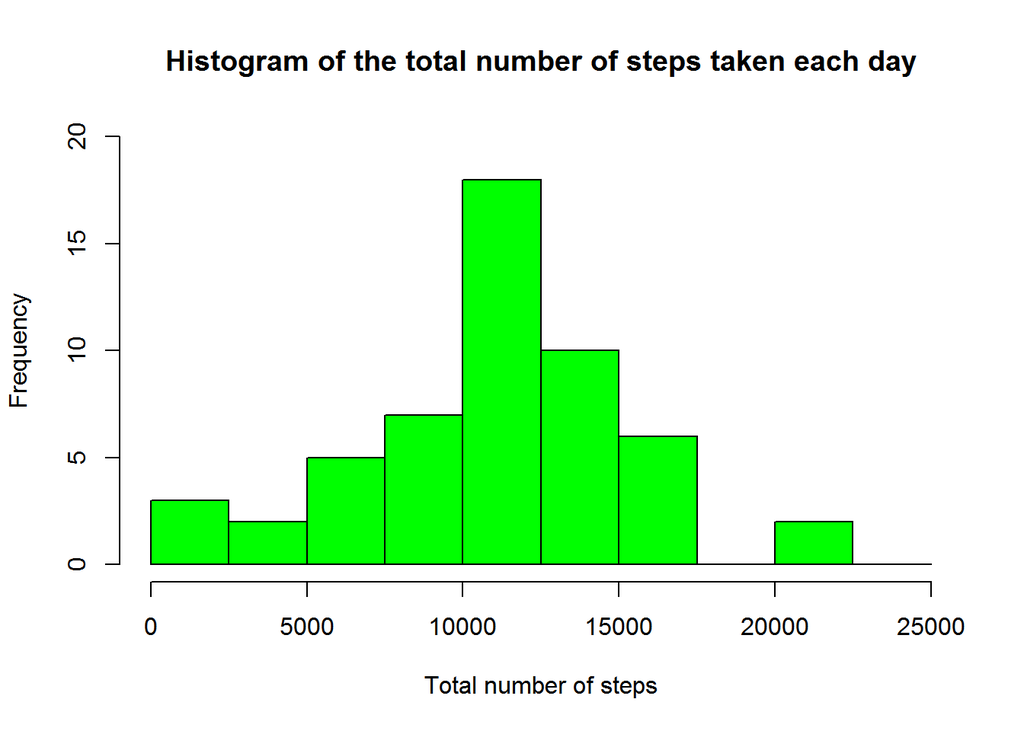

[figure not shown]

```r
steps.date <- aggregate(steps ~ date, rawdata, sum)

hist(steps.date$steps,
     breaks=seq(from=0, to=25000, by=2500),
     col="green",
     xlab="Total number of steps",
     ylim=c(0, 20),
     main="Histogram of the total number of steps taken each day")
```

```r
mean_steps <- mean(steps.date$steps, na.rm = TRUE)
median_steps <- median(steps.date$steps, na.rm = TRUE)
```

Average daily activity pattern **********************************

```r
completedata <- na.omit(rawdata)
avgSteps <- aggregate(completedata$steps, list(interval = as.numeric(as.character(completedata$interval))), FUN = "mean")

names(avgSteps)[2] <- "meanOfSteps"
```

Time-series plot ******************************

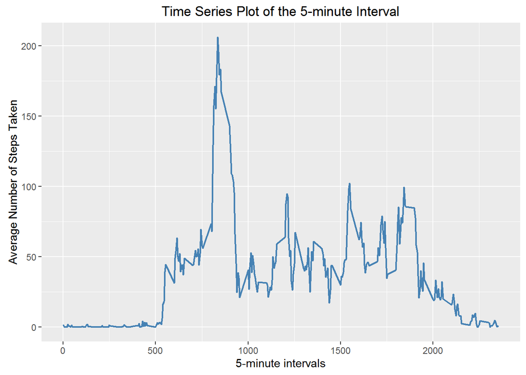

[figure not shown]

```r
p <- ggplot(avgSteps, aes(interval, meanOfSteps)) + geom_line(color = "steelblue", size = 0.8) + labs(title = "Time Series Plot of the 5-minute Interval", x = "5-minute intervals", y = "Average Number of Steps Taken")

print(p)
```

5-minute interval, on average across all the days in the dataset,that contains the maximum number of steps **********************************************************

```r
int4maxsteps <- subset(avgSteps, avgSteps[,2] == max(avgSteps[,2]))
print(int4maxsteps)
```

```
##     interval meanOfSteps
## 104      835    206.1698
```

[output not shown]

Inputing missing values ***************************************

Total no of missing values(records with missing values) **********************

```r
sum(!complete.cases(rawdata))
```

```
## [1] 2304
```

[output not shown]

Devising a strategy to put back the missing values ****************************

```r
rawdata_full <- rawdata
nas <- is.na(rawdata_full$steps)
avg_interval <- tapply(rawdata_full$steps, rawdata_full$interval, mean, na.rm=TRUE, simplify=TRUE)
rawdata_full$steps[nas] <- avg_interval[as.character(rawdata_full$interval[nas])]
```

proof that database created by putting back the missing values has no such record

```r
sum(!complete.cases(rawdata_full))
```

```
## [1] 0
```

[output not shown]

a histogram of the total number of steps taken each day *****************************

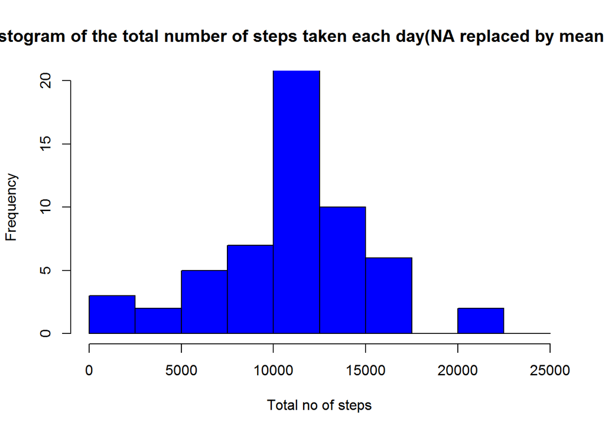

[figure not shown]

```r
steps.date <- aggregate(steps ~ date, rawdata_full, sum)
names(steps.date) <- c("date", "total")
hist(steps.date$total,
     breaks=seq(from=0, to=25000, by=2500),
     col="blue",
     xlab="Total no of steps",
     ylim=c(0, 20),
     main="Histogram of the total number of steps taken each day(NA replaced by mean value)")
```

mean and median calculated here ******************************

```r
mean(steps.date$total)
```

```
## [1] 10766.19
```

```r
median(steps.date$total)
```

```
## [1] 10766.19
```

[output not shown]

[output not shown]

Creating factor variables indicating whether the date is a weekday or weekend. *************************************

```r
rawdata_full$weekdays <- factor(format(steps.date$date, "%A"))
levels(rawdata_full$weekdays)  <- list(weekday = c("Monday", "Tuesday",
                                              "Wednesday",
                                              "Thursday", "Friday"),
                                  weekend = c("Saturday", "Sunday"))


levels(rawdata_full$weekdays)
```

```
## [1] "weekday" "weekend"
```

```r
table(rawdata_full$weekdays)
```

```
##
## weekday weekend
##   12960    4608
```

[output not shown]

[output not shown]

a panel plot containing a time series plot (i.e. type = “l”) of the 5-minute interval (x-axis) and the average number of steps taken, averaged across all weekday days or weekend days (y-axis) **************************************

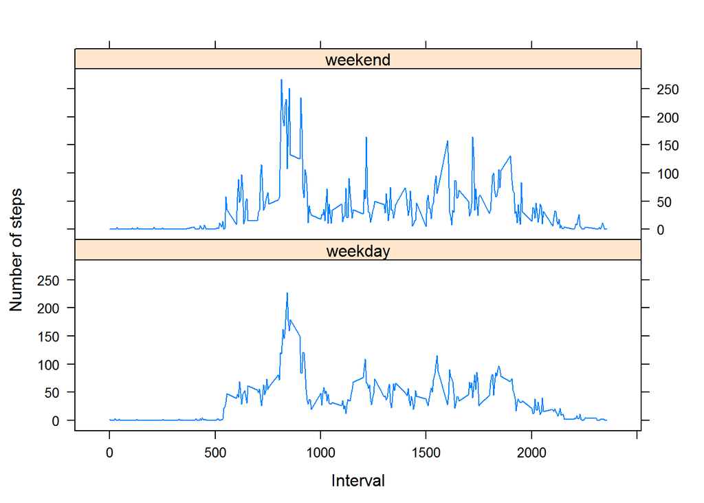

[figure not shown]

```r
averagesteps_day <- aggregate(rawdata_full$steps,
                          list(interval = as.numeric(as.character(rawdata_full$interval)),
                               weekdays = rawdata_full$weekdays),
                          FUN = "mean")

names(averagesteps_day)[3] <- "av_OfSteps"

plot2 <- xyplot(averagesteps_day$av_OfSteps ~ averagesteps_day$interval | averagesteps_day$weekdays,
                layout = c(1, 2), type = "l",
                xlab = "Interval", ylab = "Number of steps")
print(plot2)
```